# Data Background Work

Teresa Rokos

1/9/2019

## Raw data from NH HealthCost

To obtain some data on hospital costs, I copy and pasted tables from [NH HealthCost](https://nhhealthcost.nh.gov/costs/select) for particular medical procedures and services into Excel spreadsheets (one for each medical procedure/service). At first, I attempted to mimic the 8 selected services analyzed in [Cooper et al. (2018)](https://healthcarepricingproject.org/sites/default/files/20180507_variationmanuscript_0.pdf) (Inpatient, Hip Replacement, Knee Replacement, Cesarean Section, Vaginal Delivery, PTCA, Colonoscopy, and Lower Limb MRI), but the website only had data for colonoscopies and MRIs. I therefore chose 8 of my own procedures somewhat randomly but with an eye towards those that would be plausibly undifferentiated between hospitals. These initial 8 procedures were: Arthroscopic Knee Surgery (outpatient), Diagnostic colonoscopy (outpatient), Colonoscopy with biopsy (outpatient), Colonoscopy with polyp removal (outpatient), MRI - Pelvis (outpatient), X-Ray - Ankle (outpatient), MRI - Knee (outpatient), Blood test for complete blood cell count (hemoglobin).

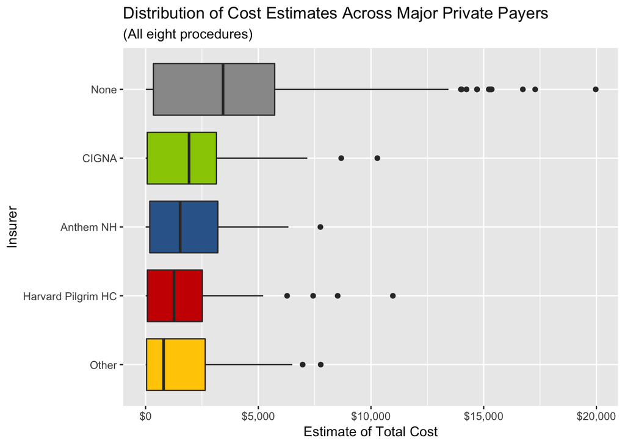

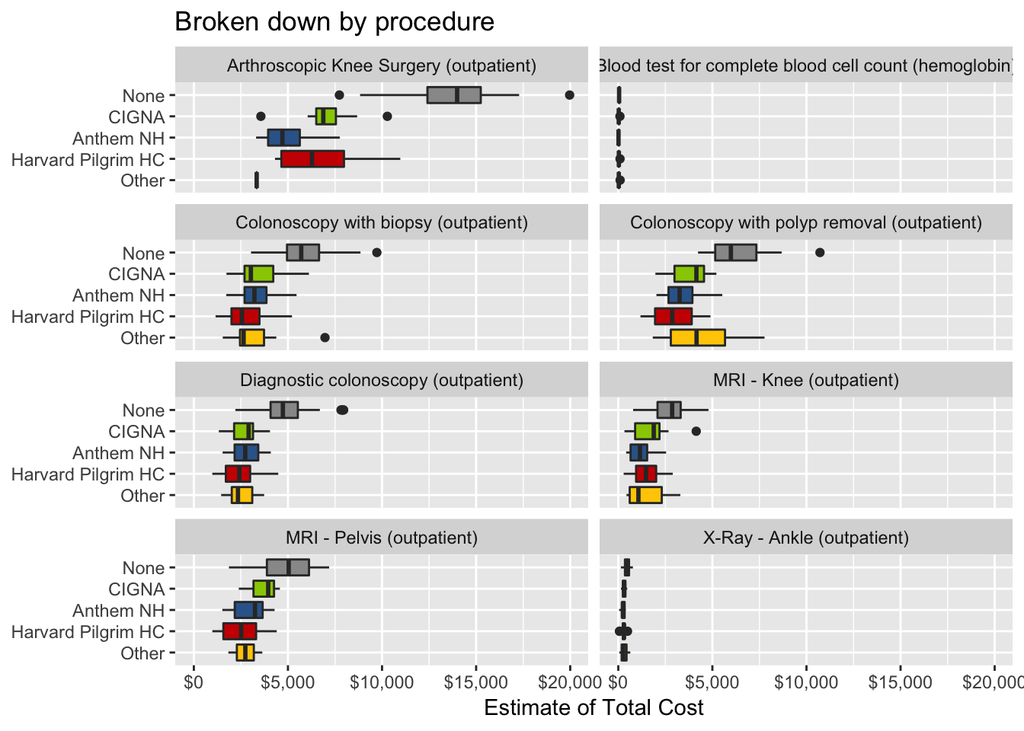

### Within Hospital Price Variation

A large part of the motivation behind this thesis is due to the existence of within-hospital variation of prices: for the exact same service, hospitals are able to charge different payers different amounts. Below are some visual examples to illustrate this variation between the three major private payers for the exact same service at the exact same hospital.

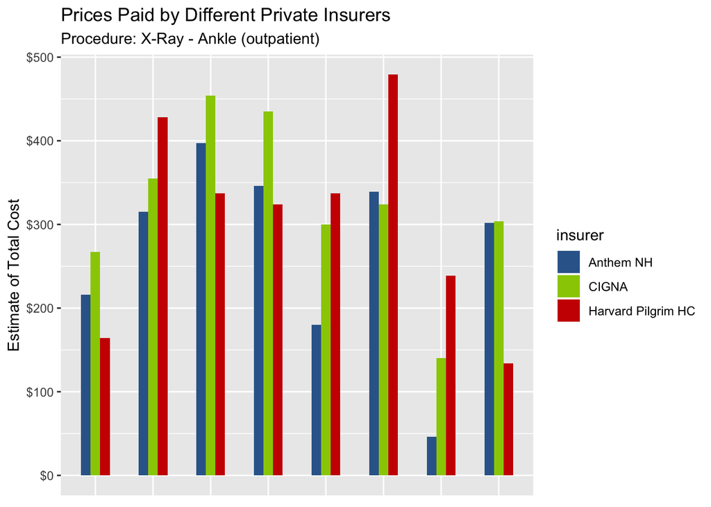